# EDA on Sleep, Legal Drugs, and Exam Stress

Joanne Jang

5/23/2017

## Introduction

I found a [dataset](https://doi.org/10.1371/journal.pone.0109490) called “Sleep Quality during Exam Stress: The Role of Alcohol, Caffeine and Nicotine,” gathered as part of a sleep study in Germany. There are 426 observations of 115 variables, but I plan on focusing on the effects of stress, exams, and legal drugs on the length, quality, and efficiency of sleep.

## Data cleaning

```r
# Libraries
library(readr)
library(dplyr)
library(ggplot2)

# Dataset
df <- read_delim("./Exam_Stress_Zunhammer_et_al_2013.csv", delim=";", col_types = cols(PSQI_ITEM1_Bedtime = col_character(), PSQI_ITEM3_Waketime = col_character(), PSQI_Time_in_Bed = col_number()))

# cleaning
df <- df %>% filter(filter_dropouts == 1)
df$time <- ordered(df$time, level = c(1, 2, 3), labels=c("pre-exam", "during", "post-exam"))
df$PSQI_SUB_Sleep_Efficiency <- ordered(df$PSQI_SUB_Sleep_Efficiency, levels=c(0, 1, 2, 3), labels=c("> 85%", "75-84%", "65-74%", "< 65%"))
df$sex <- factor(df$sex, levels=c(0,1), labels=c("female", "male"))
```

### Initial question

Do exams actually increase the perceived stress level? If so, how does the stress affect various aspects of sleep (e.g. sleep quality, sleep efficiency, sleep latency)?

### Perceived stress and exam period

[**Perceived Stress Scale (PSS)**](http://www.mindgarden.com/documents/PerceivedStressScale.pdf) measures the degree to which an individual finds a situation stressful.

My hypothesis is that PSS will increase from pre-exam period to exam period, and then dip down in the post-exam period. We can get a sense of the trend using a boxplot:

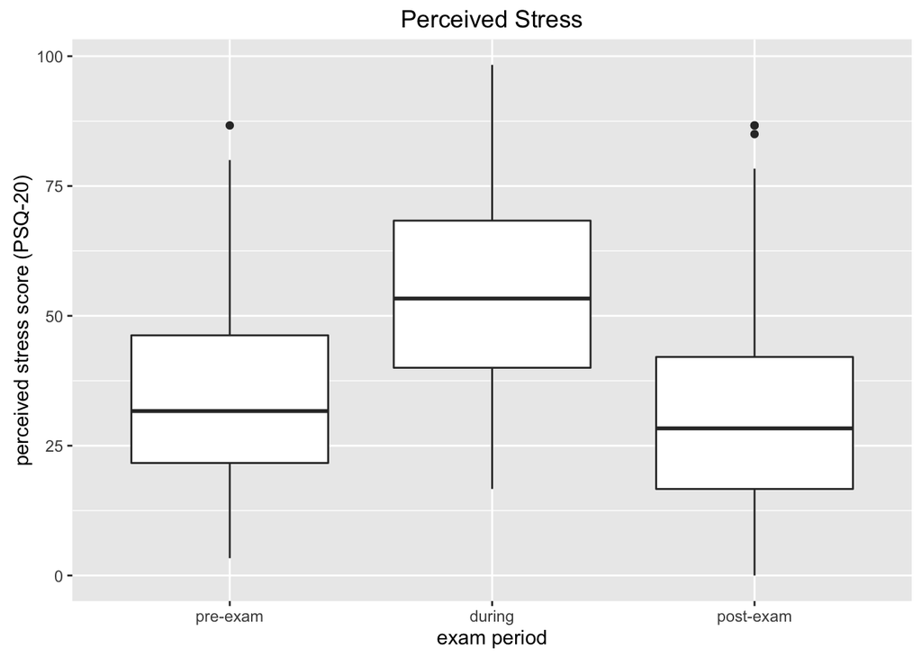

```r
df %>% ggplot(aes(x=factor(time), y=PSQ_total)) +
    geom_boxplot() +
    ggtitle("Perceived Stress") +
    labs(x = "exam period", y = "perceived stress score (PSQ-20)")
```

##### Does the number of exams have a more granular effect on PSS level?

The obvious guess would be that the more exams a student has to take, the more stressed they might be. To verify this we can plot the number of exams a student has to take against his/her PSS, and facet it by exam period.

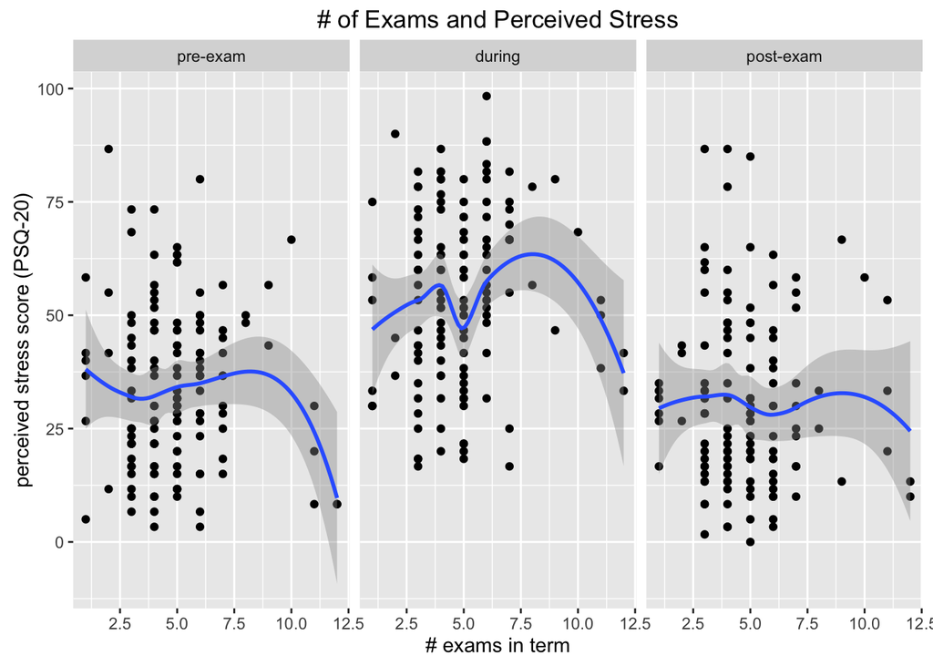

```r
df %>% ggplot(aes(x=number_of_exams_in_term, y=PSQ_total)) +
    geom_point() +
    geom_smooth() +
    facet_grid(~time) +
    ggtitle("# of Exams and Perceived Stress") +
    labs(x = "# exams in term", y = "perceived stress score (PSQ-20)")
```

Interestingly enough, it looks like there isn’t an obvious correlation between PSS and the number of exams a student has to take.

#### Perceived Stress and Sleep

The [**Regensburg Insomnia Scale (RIS)**](https://hqlo.biomedcentral.com/articles/10.1186/1477-7525-11-65) is a self-rating scale meant to assess the features of insomnia. The textbook definition of insomnia is “trouble either falling asleep or staying asleep to the point that a person perceives it bothers them the next day” (Dement’s Sleep and Dreams) Insomnia can be temporary or persistent, and one of the common precipitating circumstances of insomnia is stress.

Applying this knowledge we can hypothesize that PSS and RIS are directly correlated, and we can plot them against each other to find this out. I’m also curious as to whether there is a difference in this correlation between males and females.

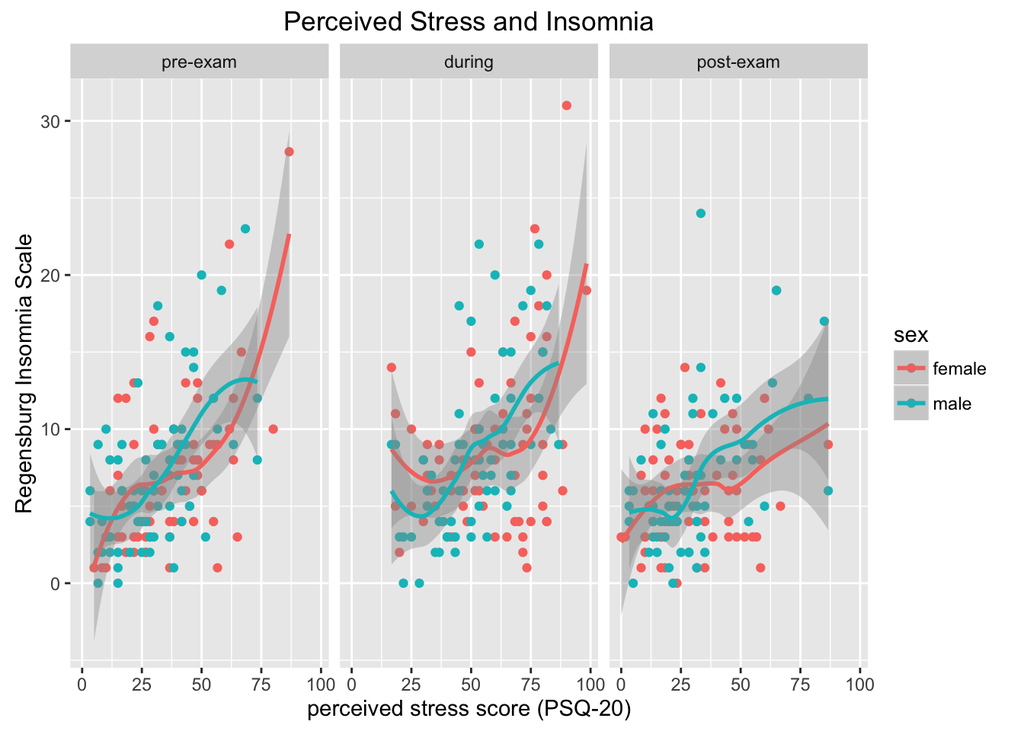

```r
df %>% ggplot(aes(x=PSQ_total, y=RIS, color = sex)) +
    geom_point() +
    geom_smooth() +
    facet_grid(~time) +
    ggtitle("Perceived Stress and Insomnia") +
    labs(x = "perceived stress score (PSQ-20)", y = "Regensburg Insomnia Scale")
```

This figure clearly indicates that perceived stress and insomnia are directly correlated. Determining whether sex is significant seems to need further statistical analysis, but we can see that the effect of stress on insomnia in the post-exam period is lower relative to the pre-exam period.

#### Does perceived stress have an effect on sleep quality as well?

[National Sleep Foundation](https://sleepfoundation.org/press-release/what-good-quality-sleep) defines good sleep quality as the following:

- high **sleep efficiency**: the time spent actually sleeping while in bed must be at least 85% of the total time spent in bed, calculated as (# hours slept / # hours spent in bed * 100)%
- low **sleep latency**: falling asleep in 30 minutes or less
- minimal arousal: waking up no more than once per night

The dataset we’re exploring uses PSQI, the [Pittsburgh Sleep Quality Index](http://www.sciencedirect.com/science/article/pii/0165178189900474) to measure sleep quality. The PSQI score is inversely correlated with good sleep quality, which means that the higher the PSQI score, the worse the sleep quality. It is said that “poor sleep” is a PSQI score >= 5.

We can plot PSS against PSQI to get a grasp on the relationship between perceived stress and sleep quality.

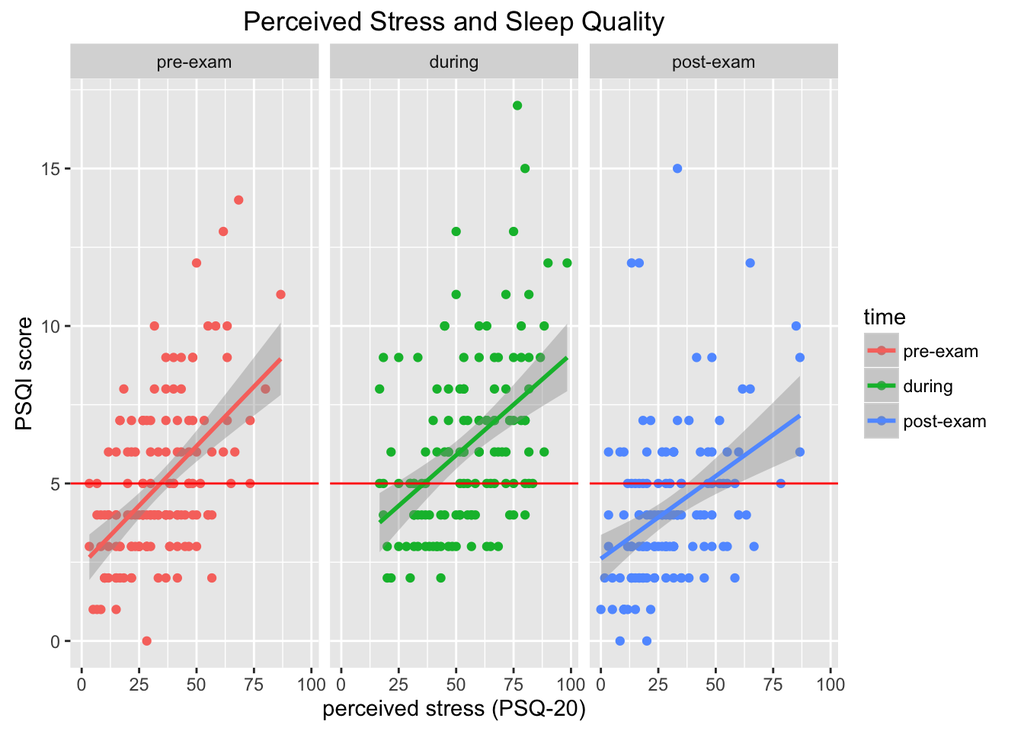

```r
df %>%
    ggplot(aes(x=PSQ_total, y=PSQI_total, color = time)) +
    geom_point() +
    geom_smooth(method='lm',formula=y~x) +
    geom_hline(yintercept=5, color="red") +
    ggtitle("Perceived Stress and Sleep Quality") +
    labs(x = "perceived stress (PSQ-20)", y = "PSQI score") +
    facet_grid(~time)
```

Here’s another take:

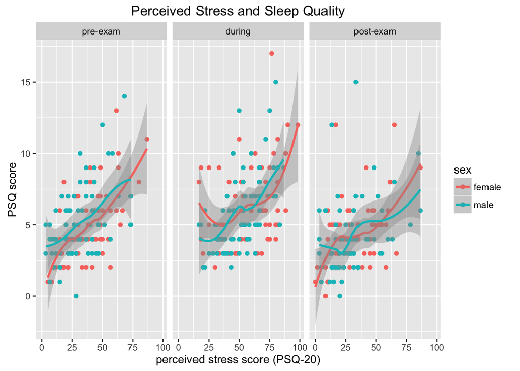

```r
df %>% ggplot(aes(x=PSQ_total, y=PSQI_total, color = sex)) +
    geom_point() +
    geom_smooth() +
    facet_grid(~time) +
    ggtitle("Perceived Stress and Sleep Quality") +
    labs(x = "perceived stress score (PSQ-20)", y = "PSQ score")
```

It looks like the perceived stress score is a very strong predictor of sleep quality, which makes sense, but is still cool to see the finding derived from data.

Taking perceived stress out of the equation, we plot the distribution of PSQI across pre-, during, and post-exam periods.

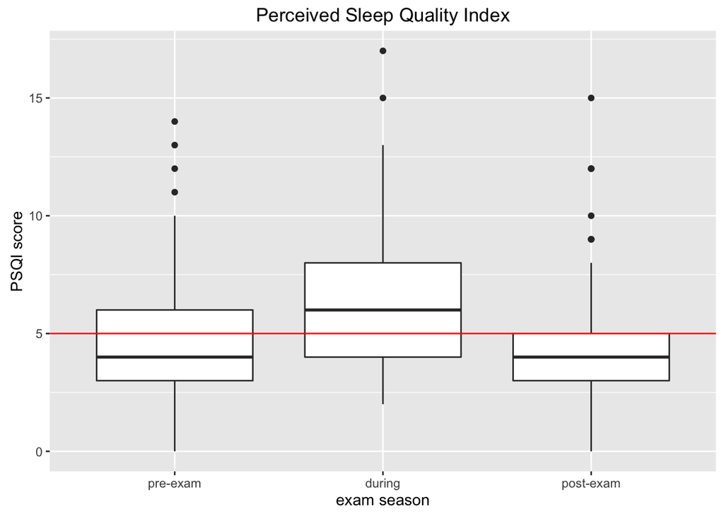

```r
df %>% ggplot(aes(x=factor(time), y=PSQI_total)) +
    geom_boxplot() +
    geom_hline(yintercept=5, color="red") +
    ggtitle("Perceived Sleep Quality Index") +
    labs(x = "exam season", y = "PSQI score")
```

The median PSQI score during exam season sits comfortably above the “poor sleep” boundary, and, while the median scores in other seasons lie below it.

#### Sleep time and efficiency comparison

We further investigate the effect of exam periods on sleep efficiency and the total length of sleep.

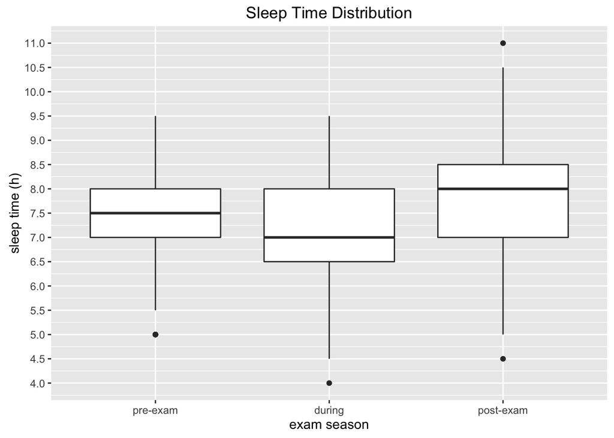

```r
df %>% ggplot(aes(x=factor(time), y=PSQI_ITEM4_Sleep_Time)) +
    geom_boxplot() +
    ggtitle("Sleep Time Distribution") +
    labs(x = "exam season", y = "sleep time (h)") +
    scale_y_continuous(breaks=seq(2,12,0.5))
```

```r
summary(df$course_of_study)
```

[output not shown]

The median seems to sit +/- 30 minutes of 7.5 hours, with the lowest being during exam period and the highest being post-exam period.

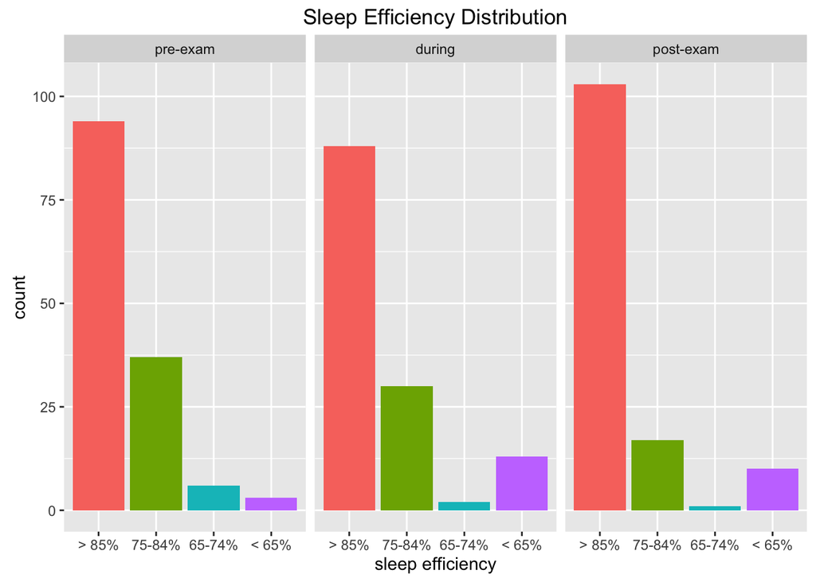

```r
df %>% subset(!is.na(PSQI_SUB_Sleep_Efficiency)) %>%
    ggplot(aes(x=PSQI_SUB_Sleep_Efficiency)) +
    geom_bar(stat="count", aes(fill=factor(PSQI_SUB_Sleep_Efficiency))) +
    ggtitle("Sleep Efficiency Distribution") +
    facet_grid(. ~ time) +
    labs(x = "sleep efficiency", y = "count") +
    theme(legend.position="none")
```

Sleep efficiency slightly dips during exam period.

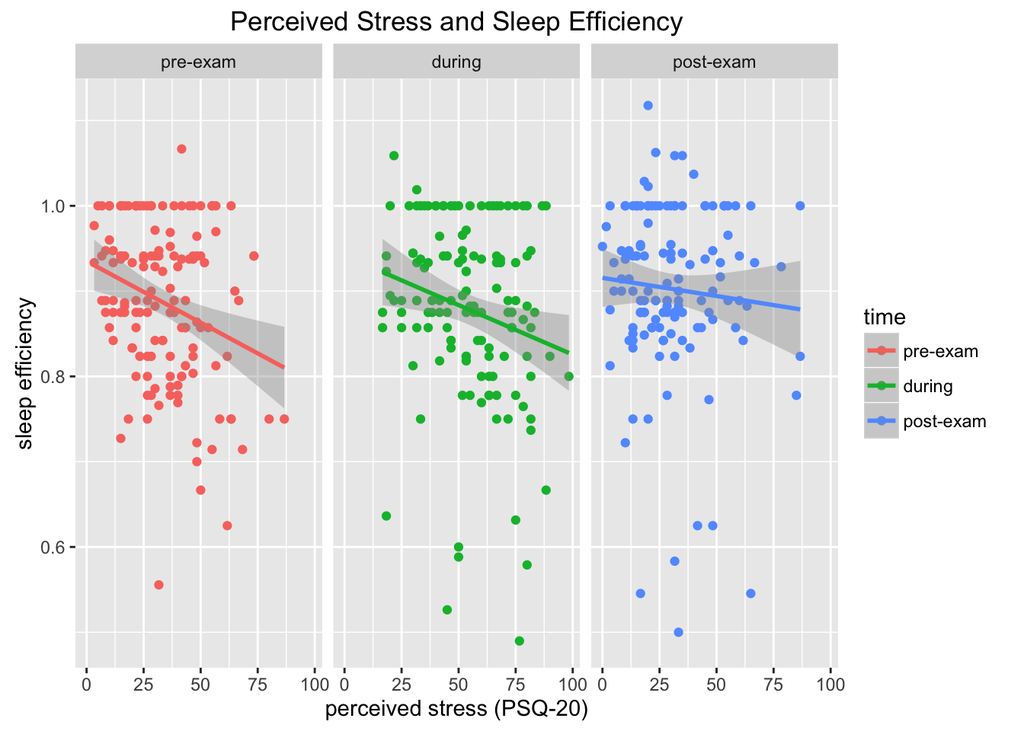

```r
df %>%
    ggplot(aes(x=PSQ_total, y=Sleep_Efficiency, color = time)) +
    geom_point() +
    geom_smooth(method='lm',formula=y~x) +
    ggtitle("Perceived Stress and Sleep Efficiency") +
    labs(x = "perceived stress (PSQ-20)", y = "sleep efficiency") +
    facet_grid(~time)
```

Sleep efficiency seems to decrease as perceived stress increases, but sleep efficiency is least affected after exam period.

## Legal drugs and sleep quality

One strong predictor of sleep quality and latency we haven’t acknowledged yet is the consumption of “legal drugs”: caffeine, nicotine, and alcohol.

#### Caffeine and Sleep Latency

Caffeine has the effect of appearing as adenosine to nerve cells and binding to the adenosine receptors to keep the brain from detecting adenosine and slowing down the nerve activity. My prediction is that caffeine will have a negative impact on sleep latency.

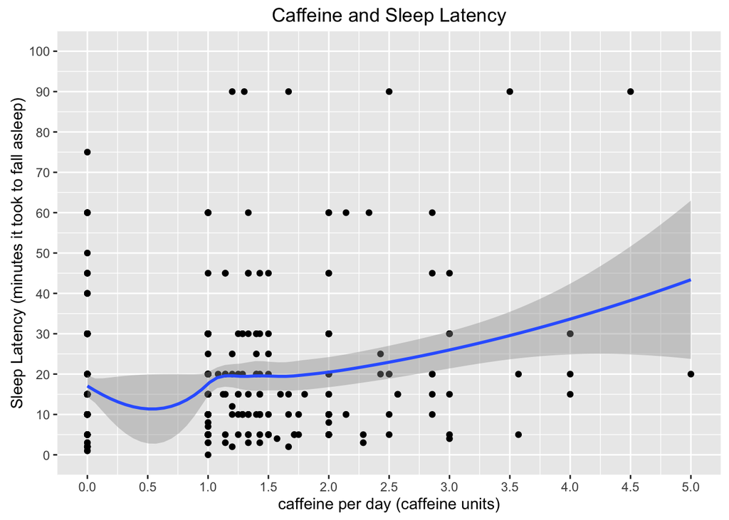

```r
df %>% ggplot(aes(x= caffeine_per_day, y=PSQI_ITEM2_Sleep_Latency)) +
    geom_point() +
    geom_smooth() +
    scale_y_continuous(limit = c(0,100), breaks=seq(0, 100, 10)) +
    scale_x_continuous(limit = c(0, 5), breaks = seq(0, 5, 0.5)) +
    ggtitle("Caffeine and Sleep Latency") +
    labs(x = "caffeine per day (caffeine units)", y = "Sleep Latency (minutes it took to fall asleep)")
```

#### Sleep quality and caffeine/nicotine/alcohol

In this dataset, an alcoholic drink is measured in standard drinks (333 mL of beer), a unit of caffeine is measured as 200 mL of coffee or tea, and nicotine is measured in number of cigarettes.

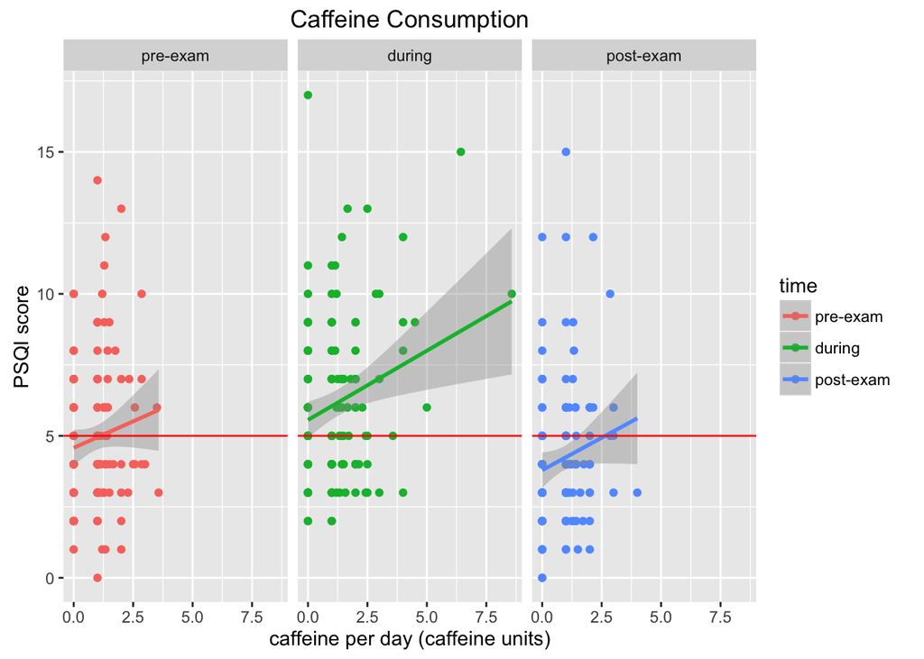

```r
df %>% subset(!is.na(caffeine_per_day)) %>%
    ggplot(aes(x=caffeine_per_day, y=PSQI_total, color = time)) +
    geom_point() +
    geom_smooth(method='lm',formula=y~x) +
    geom_hline(yintercept=5, color="red") +
    ggtitle("Caffeine Consumption") +
    labs(x = "caffeine per day (caffeine units)", y = "PSQI score") +
    facet_grid(~time)
```

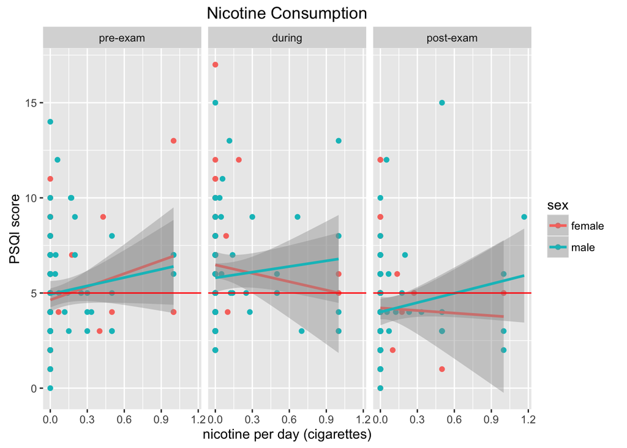

```r
df %>% subset(!is.na(nicotione_per_day)) %>%
    ggplot(aes(x=nicotione_per_day, y=PSQI_total, color = sex)) +
    geom_point() +
    geom_smooth(method='lm',formula=y~x) +
    geom_hline(yintercept=5, color="red") +
    ggtitle("Nicotine Consumption") +
    labs(x = "nicotine per day (cigarettes)", y = "PSQI score") +
    facet_grid(~time)
```

Purely based on the line of best fit, it looks like nicotine has a positive effect on sleep quality for females during and after the exam period, but it’s important to note that there aren’t many femal smokers to start with, so the trend line doesn’t say much. However, we can see that nicotine consumption does have a slightly negative impact on sleep quality.

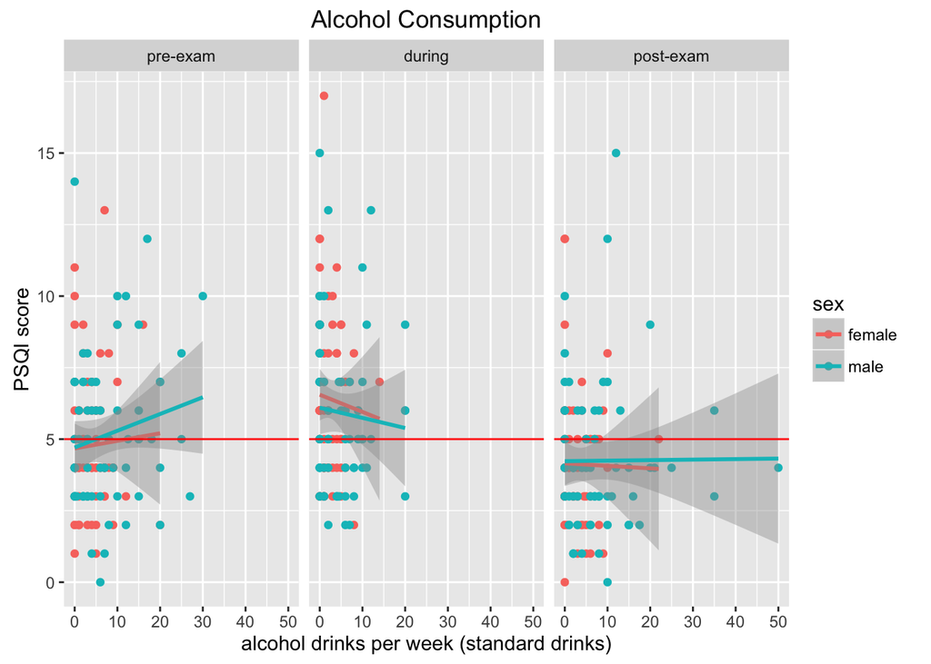

```r
df %>% subset(!is.na(alcohol_drinks_per_week)) %>%
    ggplot(aes(x=alcohol_drinks_per_week, y=PSQI_total, color = sex)) +
    geom_point() +
    geom_smooth(method='lm',formula=y~x) +
    geom_hline(yintercept=5, color="red") +
    ggtitle("Alcohol Consumption") +
    labs(x = "alcohol drinks per week (standard drinks)", y = "PSQI score") +
    facet_grid(~time)
```

## Conclusion

Perceived stress level dominates as a predictor of many aspects of sleep (including quality, efficiency, and insomnia), and whether or not a student has a set of exams coming up is a strong predictor of the perceived stress level. Therefore we can conclude that exams have a nontrivial amount of influence on students’ mental health and sleep hygiene.